# Log crossing activity in a tropical rainforest

Juan S. Vargas Soto

## Introduction

The goal of this project was to study how trees that have fallen over rivers and streams in tropical forests—effectively creating a temporary bridge—are used by different species of terrestrial vertebrates, focusing particularly on medium to large mammals and ground birds. In tropical wet forests, rivers and streams may constitute significant barriers for movement, limiting the dispersal of animals. However, these forests also have frequent tree falls, which can happen by rivers and connect both sides. Here, we aim to determine if these fallen trees effectively serve as bridges, and which species of animals are able to use them.

## Results

### Effort

The total effort was 2374 trap-days, the shortest effort was 12 days at a station, and the longest 342 (counting both cameras together).

```
## # A tibble: 26 × 3
## # Groups:   station [18]
##    station camera cumeffort
##    <chr>   <chr>      <int>
##  1 CLOG01  A            190
##  2 CLOG02  A             38
##  3 CLOG03  A            119
##  4 CLOG03  B             86
##  5 CLOG04  A            112
##  6 CLOG05  A              2
##  7 CLOG05  B             90
##  8 CLOG06  A            149
##  9 CLOG06  B             38
## 10 CLOG07  A             91
## # ℹ 16 more rows
```

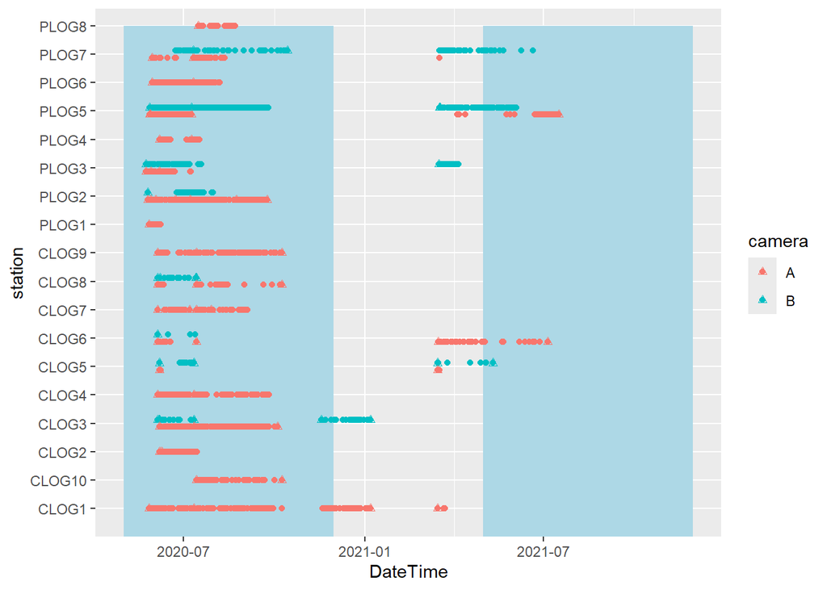

### Species observed

Summary of detections of different species of mammals and birds around logs over rivers

| Species | Detections (n) | Cross freq. (%) |
| --- | --- | --- |
| tamandua | 208 | 87.5 |
| coati | 188 | 89.9 |
| opossum_common | 141 | 93.6 |
| tayra | 87 | 87.4 |
| ocelot | 86 | 94.2 |
| skunk_striped | 84 | 92.9 |
| curassow_great | 70 | 41.4 |
| agouti | 37 | 35.1 |
| puma | 37 | 83.8 |
| rodent | 29 | 75.9 |
| squirrel_uid | 23 | 43.5 |
| paca | 19 | 0.0 |
| opossum_foureyed | 18 | 88.9 |
| peccary_collared | 8 | 0.0 |
| margay | 6 | 100.0 |
| racoon_crabeating | 6 | 50.0 |
| raccoon | 4 | 100.0 |
| opossum_water | 3 | 66.7 |
| squirrel_monkey | 3 | 66.7 |
| capuchin_whitefaced | 2 | 100.0 |
| jaguarundi | 2 | 50.0 |
| otter | 2 | 0.0 |
| guan_crested | 1 | 100.0 |
| opossum_uid | 1 | 0.0 |
| tapir | 1 | 0.0 |

There seem to be some important differences in the probability of crossing across species, some cross nearly every occasion while others rarely do. These observations, however, must be analyzed only for cameras where the same bank is visible.

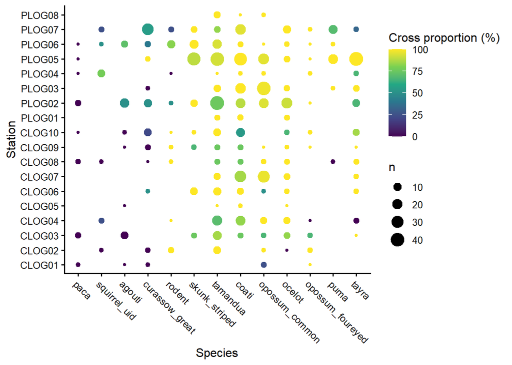

Activity and crossing probability for wild vertebrates near logs above rivers in the Osa Wildlife Refuge, Costa Rica

We see that the proportion of crossings is mostly consistent across logs for the same species, as seen from the color range observed vertically, with maybe the exception of tayras. This proportion varies mainly across species. The diversity of species at each log is also different. Logs like PLOG05, PLOG06, and PLOG02 detected 15, 14, and 13 species, respectively. PLOG01 and PLOG08 in contrast each recorded only three different species.

### Factors influencing use of logs

We were interested in determining factors that could influence the activity at the log and the probability of crossing. We measured different variables about the log (width, length, height above the water), the river or stream characteristics at that spot (width, depth, flow), and the amount of vegetation (canopy cover). Given the number of covariates, we attempted to reduce it to fewer dimensions by testing for significant correlations among them, and by determining the principal components.

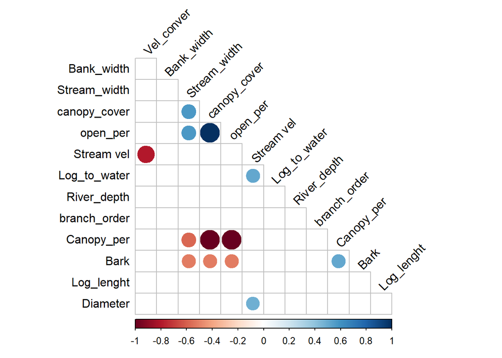

Correlation among covariates for logs across rivers in the Osa Wildlife Refuge

The covariates were for the most part not strongly correlated to each other. There were some positive correlations between stream width, canopy cover and open percentage. There was also a negative correlation between stream width, canopy cover, and percentage open, and bark. Additionally, stream velocity was positively correlated with log diameter and height above water, and negatively correlated with the velocity of the stream. There are nonetheless many covariates, and it could make sense to reduce the dimensions using a principal components analysis (PCA).

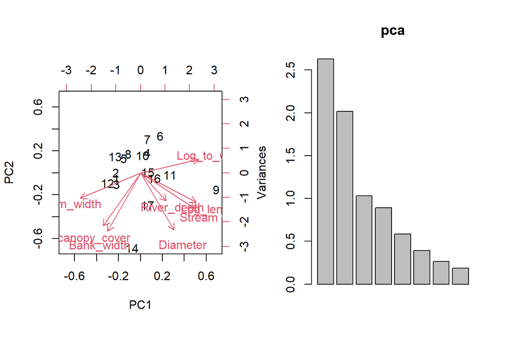

Principal component analysis of covariates for logs over rivers in the Osa Wildlife Refuge

It may be hard to summarize the variables in fewer than 3 components. Because of this it makes more sense to keep the original variables, and select covariates to include based on relevance and model fit. Here are the variables that I believe should be relevant:

- Log diameter
- Stream width
- Height above water
- Seasonality for frequency and probability of crossing

### Number of species crossing

There doesn’t seem to be any factor that determines the number of species crossing at each station. The only one where it could seem there is an important effect is the log diameter, where wider logs increase the number of species that cross it.

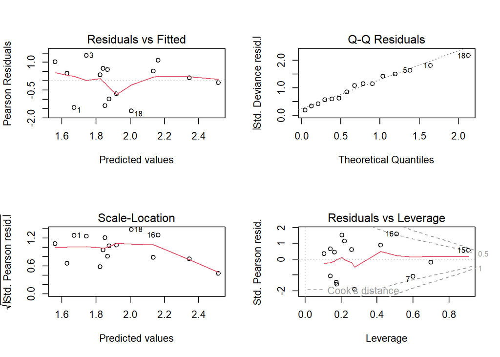

```
##
## Call:
## glm(formula = n ~ Log_to_water + Diameter + Stream_width + River_depth,
##     family = poisson(link = "log"), data = d1)
##
## Coefficients:
##              Estimate Std. Error z value Pr(>|z|)
## (Intercept)   1.95536    0.10298  18.987   <2e-16 ***
## Log_to_water  0.03182    0.13530   0.235   0.8141
## Diameter      0.18116    0.09314   1.945   0.0518 .
## Stream_width -0.11533    0.09076  -1.271   0.2038
## River_depth   0.11243    0.09473   1.187   0.2353
## ---
## Signif. codes:  0 '***' 0.001 '**' 0.01 '*' 0.05 '.' 0.1 ' ' 1
##
## (Dispersion parameter for poisson family taken to be 1)
##
##     Null deviance: 22.838  on 14  degrees of freedom
## Residual deviance: 15.001  on 10  degrees of freedom
##   (3 observations deleted due to missingness)
## AIC: 80.628
##
## Number of Fisher Scoring iterations: 4
```

### Crossing frequency

```
## # A tibble: 18 × 4
##    station     n   freq  prop
##    <chr>   <int>  <dbl> <dbl>
##  1 CLOG01     10 0.0526 0.2
##  2 CLOG02     25 0.658  0.76
##  3 CLOG03     55 0.268  0.564
##  4 CLOG04     66 0.589  0.712
##  5 CLOG05      5 0.0543 0.8
##  6 CLOG06     37 0.198  0.946
##  7 CLOG07     75 0.824  0.933
##  8 CLOG08     36 0.221  0.694
##  9 CLOG09     29 0.232  0.517
## 10 CLOG10     49 0.570  0.633
## 11 PLOG01     13 1.08   1
## 12 PLOG02    160 0.865  0.762
## 13 PLOG03     87 0.725  0.966
## 14 PLOG04     22 0.55   0.727
## 15 PLOG05    217 0.635  0.945
## 16 PLOG06     71 1.04   0.831
## 17 PLOG07     99 0.352  0.727
## 18 PLOG08     10 0.270  1
```

We analyze the number of animals seen crossing. For this, we divide the detection into weekly detection frequencies. The weeks that the camera was working are in a csv file.

Below I create a database with the number of weekly detection for every station and species

With the database, we can run the models. First I will find the most appropriate random effect structure. The base frequency (intercept) should be related to the species, some are just more abundant than others. Previous studies have also found that seasonality impacts different species differently, so this can also be included as a random effect. For this first step I will include all covariates of interest, i.e. the stream width and depth, log height, log width, log length, and season. The response variable is the number of crossings by species per week.

```
##                 df      AIC
## freqmodels[[1]]  9 3303.132
## freqmodels[[2]]  7 3306.275
## freqmodels[[3]]  6 3442.327
```

```
## Generalized linear mixed model fit by maximum likelihood (Laplace
##   Approximation) [glmerMod]
##  Family: poisson  ( log )
## Formula: n ~ Log_lenght + Diameter + Log_to_water + River_depth + season +
##     (1 + season | species)
##    Data: dat_glmm_week_freq
##
##       AIC       BIC    logLik -2*log(L)  df.resid
##    3303.1    3352.8   -1642.6    3285.1      1833
##
## Scaled residuals:
##     Min      1Q  Median      3Q     Max
## -1.1778 -0.6486 -0.4689 -0.2314 15.4786
##
## Random effects:
##  Groups  Name        Variance Std.Dev. Corr
##  species (Intercept) 0.7654   0.8749
##          seasonrainy 0.3825   0.6185   -0.80
## Number of obs: 1842, groups:  species, 12
##
## Fixed effects:
##              Estimate Std. Error z value Pr(>|z|)
## (Intercept)  -1.56492    0.34683  -4.512 6.42e-06 ***
## Log_lenght    0.50974    0.07031   7.250 4.17e-13 ***
## Diameter      0.20595    0.03422   6.018 1.77e-09 ***
## Log_to_water  0.38989    0.05730   6.804 1.02e-11 ***
## River_depth  -0.19265    0.03774  -5.105 3.31e-07 ***
## seasonrainy   0.47345    0.29882   1.584    0.113
## ---
## Signif. codes:  0 '***' 0.001 '**' 0.01 '*' 0.05 '.' 0.1 ' ' 1
##
## Correlation of Fixed Effects:
##             (Intr) Lg_lng Diamtr Lg_t_w Rvr_dp
## Log_lenght   0.024
## Diameter    -0.029 -0.215
## Log_to_watr  0.040  0.435 -0.101
## River_depth -0.046 -0.213 -0.379  0.050
## seasonrainy -0.879 -0.017 -0.025 -0.028  0.038
```

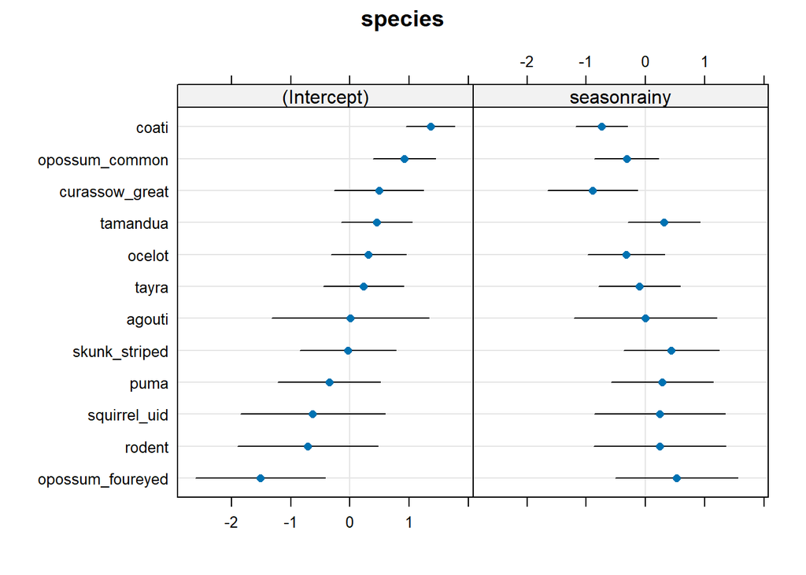

The random species intercept estimates suggest that four-eyed opossums have lower baseline activity than the rest of the species, and that common opossums and coatis have higher than average. The season seems to only affect curassows and coatis. Their use of logs would decrease in rainy season.

```
## # Check for zero-inflation
##
##    Observed zeros: 1401
##   Predicted zeros: 1257
##             Ratio: 0.90
```

```
## # Overdispersion test
##
##        dispersion ratio =    1.975
##   Pearson's Chi-Squared = 3620.308
##                 p-value =  < 0.001
```

The model seems to be zero-inflated and overdispersed. It is recommended to use a zero-inflated Poisson or zero-inflated negative binomial distribution instead.

#### Zero-inflated model

First I specify a zero-inflated Poisson mixed model. This model requires specifying a model for the zero-inflation process, i.e. the process linked to additional 0s in the observed data. For simplicity I set this model as a intercept-only model, so the additional 0s will be linked to a constant. This assumes that zero-inflation is uniform across stations and species.

```
##                           df      AIC
## zifreqmodel               10 3056.061
## zifreqmodel2               8 3058.162
## freqmodels$full_RndIntSsn  9 3303.132
```

The best model in this case is the one with both random effects (intercept and season). Both zero-inflated models have a significantly lower AIC than the Poisson model

```
## # Check for zero-inflation
##
##    Observed zeros: 1401
##   Predicted zeros: 1430
##             Ratio: 1.02
```

```
## # Overdispersion test
##
##  dispersion ratio = 1.526
##           p-value =  0.16
```

```
##              df      AIC
## zifreqmodel  10 3056.061
## zifreqmodel2  8 3058.162
## zifreqmodel3 11 3029.136
## zifreqmodel4 11 3036.205
```

Out of these, the best model according to AIC is the one that includes station as a random effect in the binomial false zero model.

```
## # Check for zero-inflation
##
##    Observed zeros: 1401
##   Predicted zeros: 1427
##             Ratio: 1.02
```

```
## # Overdispersion test
##
##  dispersion ratio = 1.480
##           p-value = 0.184
```

#### Negative binomial models

```
##               df      AIC
## freqmodel_nb2  9 2958.331
## freqmodel_nb  11 2960.770
## zinbfreqmod2  10 2960.331
## zinbfreqmod   12 2962.770
```

All these models have lower AIC than the ones with a Poisson distribution. Out of them, the best model is the one with negative binomial distribution and season as a fixed effect.

```
## # Check for zero-inflation
##
##    Observed zeros: 1401
##   Predicted zeros: 1444
##             Ratio: 1.03
```

```
## # Overdispersion test
##
##  dispersion ratio = 1.321
##           p-value = 0.152
```

```
##  Family: nbinom1  ( log )
## Formula:
## n ~ Log_lenght + Diameter + Log_to_water + River_depth + season +
##     Stream_width + (1 | species)
## Data: dat_glmm_week_freq
##
##       AIC       BIC    logLik -2*log(L)  df.resid
##    2958.3    3008.0   -1470.2    2940.3      1833
##
## Random effects:
##
## Conditional model:
##  Groups  Name        Variance Std.Dev.
##  species (Intercept) 0.2344   0.4841
## Number of obs: 1842, groups:  species, 12
##
## Dispersion parameter for nbinom1 family (): 1.08
##
## Conditional model:
##              Estimate Std. Error z value Pr(>|z|)
## (Intercept)  -1.43424    0.23044  -6.224 4.85e-10 ***
## Log_lenght    0.23410    0.10857   2.156 0.031071 *
## Diameter      0.23231    0.05088   4.566 4.98e-06 ***
## Log_to_water  0.27296    0.07634   3.576 0.000349 ***
## River_depth  -0.10718    0.05046  -2.124 0.033665 *
## seasonrainy   0.34961    0.17853   1.958 0.050196 .
## Stream_width -0.04973    0.04898  -1.015 0.309995
## ---
## Signif. codes:  0 '***' 0.001 '**' 0.01 '*' 0.05 '.' 0.1 ' ' 1
```

Conclusion. I fit a negative binomial mixed effects model with the number of detections as a response variable. I included a random intercept species. I included the log length, log width, height above water, stream width, stream depth, and season as fixed effects.

```
## $fit
## mu_predict mu_predict
##  0.2382955  0.3380269
##
## $se.fit
## mu_predict mu_predict
## 0.05491322 0.05455730
```

```
## # Intraclass Correlation Coefficient
##
##     Adjusted ICC: 0.135
##   Unadjusted ICC: 0.124
```

#### Plot

##### Data plots

Plots of crossing frequency wrt to log covariates.

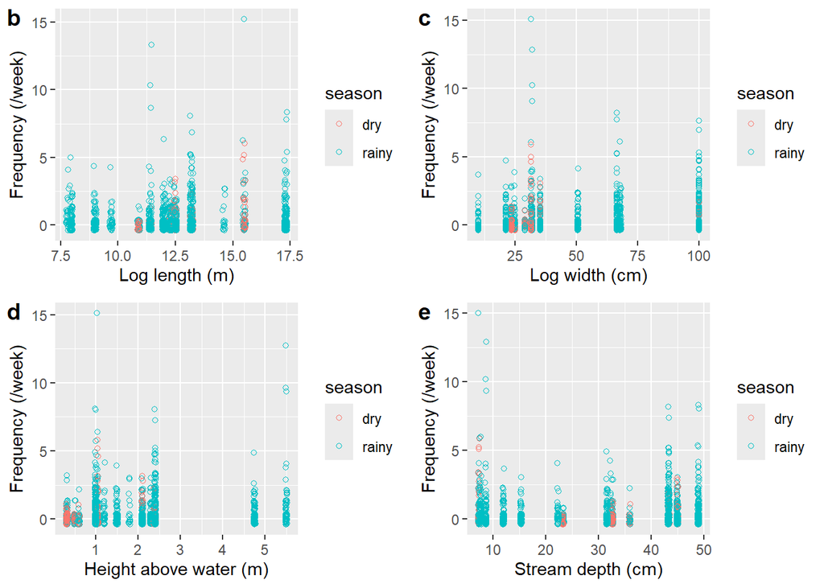

##### Model predictions

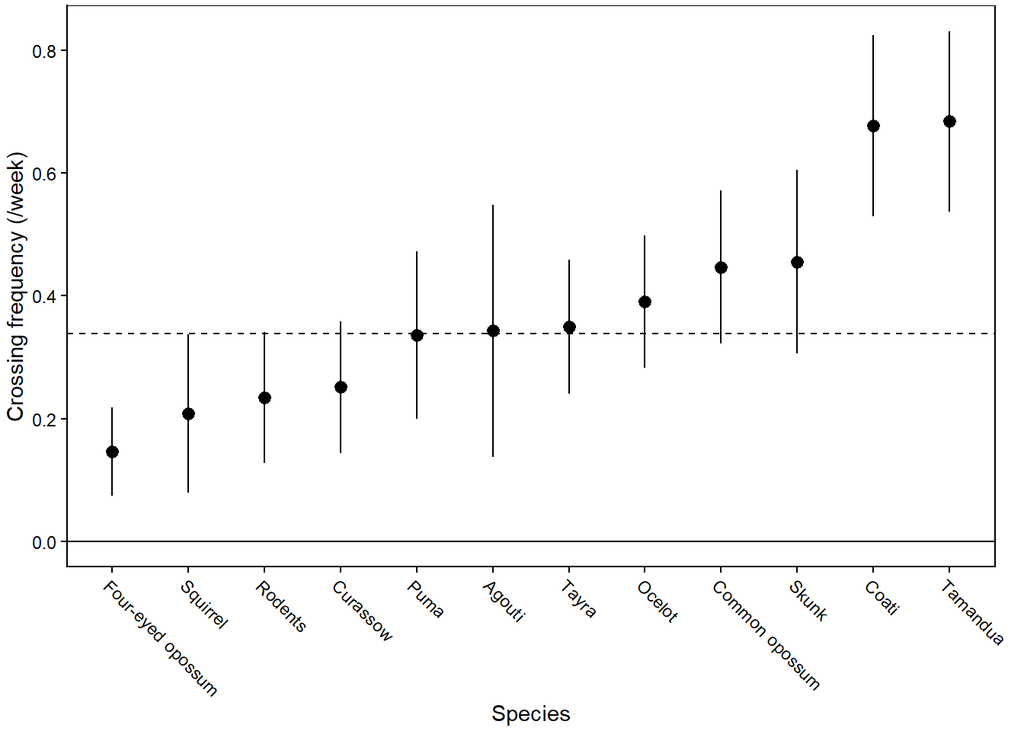

Export model predictions to figure.

Export combined figures (data points and model predicted lines)

### Probability of crossing

To analyze how the probability of crossing is influenced by different covariates, we used a binomial generalized linear model (GLM), where the response variable was whether the animal crossed or not for every observation, and with some selected covariates as predictors. In addition to the variables seen previously, I will also include the season, as rain will have significant effects on water level and flow. For one, the rain affects the water level, some streams will become easier to pass, rendering the logs unnecessary. Secondly, animals change their activity ranges in rainy and dry seasons, so there may be differences in overall activity near the streams. There are some clear differences between the species in their behavior and whether they tend to cross logs or not. We include a random effect of species to account for these differences. For this model, we include only species that had 10 or more records over the study period. In this analysis we only use cameras were you can see enough of the proximate bank to detect animals that do not cross. Most cameras were directed towards the middle of the log, so they would only be triggered once an animal was on the log.

```
##     df      AIC
## mm1  7 283.4917
## mm2  6 287.0227
```

The first model, with season, performs better than the one without.

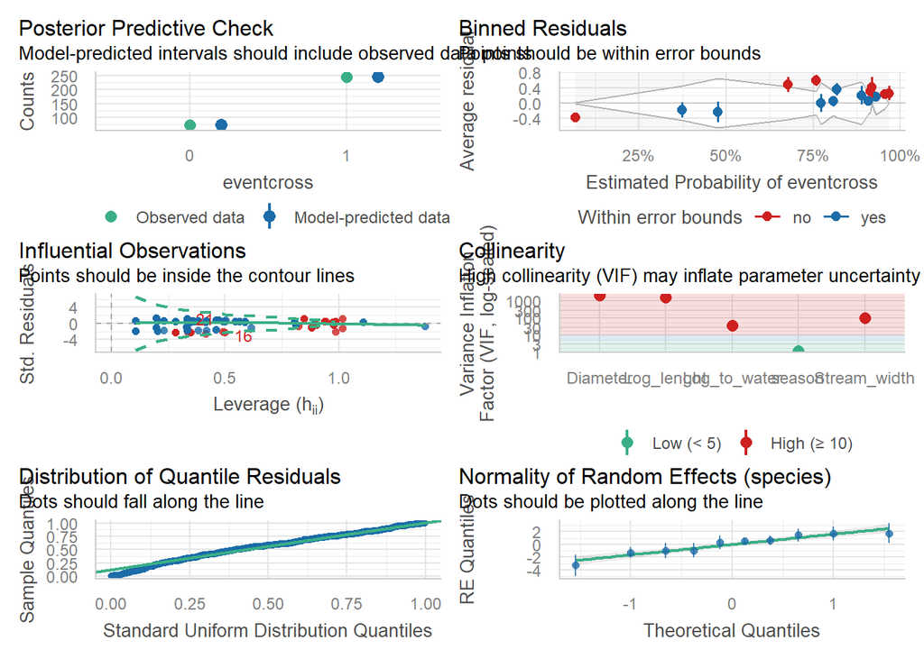

The model performs quite poorly, there is significant VIF, probably due to the low number of logs. Let’s reduce the number of variables. I will do this stepwise, removing first the covariates with the highest VIF.

```
## # Check for Multicollinearity
##
## Low Correlation
##
##    Term  VIF         VIF 95% CI adj. VIF Tolerance Tolerance 95% CI
##  season 1.20 [   1.09,    1.42]     1.09      0.83     [0.70, 0.91]
##
## High Correlation
##
##          Term     VIF         VIF 95% CI adj. VIF Tolerance Tolerance 95% CI
##  Log_to_water   36.88 [  29.87,   45.59]     6.07      0.03     [0.02, 0.03]
##      Diameter 2203.33 [1778.44, 2729.79]    46.94  4.54e-04     [0.00, 0.00]
##    Log_lenght 1697.85 [1370.46, 2103.51]    41.20  5.89e-04     [0.00, 0.00]
##  Stream_width  103.42 [  83.58,  128.03]    10.17  9.67e-03     [0.01, 0.01]
```

Log diameter and length have very high VIF, we remove diameter first.

```
## # Check for Multicollinearity
##
## Low Correlation
##
##    Term  VIF     VIF 95% CI adj. VIF Tolerance Tolerance 95% CI
##  season 1.20 [ 1.09,  1.42]     1.09      0.83     [0.70, 0.91]
##
## High Correlation
##
##          Term   VIF     VIF 95% CI adj. VIF Tolerance Tolerance 95% CI
##  Log_to_water 17.98 [14.62, 22.17]     4.24      0.06     [0.05, 0.07]
##    Log_lenght 36.18 [29.31, 44.73]     6.02      0.03     [0.02, 0.03]
##  Stream_width 29.87 [24.21, 36.90]     5.47      0.03     [0.03, 0.04]
##   River_depth 27.04 [21.93, 33.40]     5.20      0.04     [0.03, 0.05]
```

Following the same process, we eliminate also log length and river depth.

```
## # Check for Multicollinearity
##
## Low Correlation
##
##          Term  VIF   VIF 95% CI adj. VIF Tolerance Tolerance 95% CI
##  Log_to_water 1.02 [1.00, 3.51]     1.01      0.98     [0.28, 1.00]
##  Stream_width 1.14 [1.06, 1.38]     1.07      0.87     [0.73, 0.95]
##        season 1.16 [1.07, 1.39]     1.08      0.86     [0.72, 0.94]
```

```
## Generalized linear mixed model fit by maximum likelihood (Laplace
##   Approximation) [glmerMod]
##  Family: binomial  ( logit )
## Formula: eventcross ~ Log_to_water + Stream_width + season + (1 | species)
##    Data: dat_glmm
##
##       AIC       BIC    logLik -2*log(L)  df.resid
##     281.8     300.6    -135.9     271.8       312
##
## Scaled residuals:
##     Min      1Q  Median      3Q     Max
## -4.7730  0.1949  0.3021  0.4925  1.2088
##
## Random effects:
##  Groups  Name        Variance Std.Dev.
##  species (Intercept) 2.77     1.664
## Number of obs: 317, groups:  species, 10
##
## Fixed effects:
##              Estimate Std. Error z value Pr(>|z|)
## (Intercept)  -1.12855    1.05136  -1.073   0.2831
## Log_to_water  0.32684    0.21914   1.491   0.1358
## Stream_width -0.03735    0.16660  -0.224   0.8226
## seasonrainy   2.26546    0.96453   2.349   0.0188 *
## ---
## Signif. codes:  0 '***' 0.001 '**' 0.01 '*' 0.05 '.' 0.1 ' ' 1
##
## Correlation of Fixed Effects:
##             (Intr) Lg_t_w Strm_w
## Log_to_watr  0.202
## Stream_wdth -0.162  0.027
## seasonrainy -0.830 -0.133  0.348
```

This model does not have strong collinearities, but we can see if there is a more parsimonious model, we remove the covariate with the lowest z value.

```
##                                                                         df
## mm1                                                                      7
## update(mm1, . ~ . - Diameter - Log_lenght - River_depth)                 5
## update(mm1, . ~ . - Diameter - Log_lenght - River_depth - Stream_width)  4
##                                                                              AIC
## mm1                                                                     283.4917
## update(mm1, . ~ . - Diameter - Log_lenght - River_depth)                281.7839
## update(mm1, . ~ . - Diameter - Log_lenght - River_depth - Stream_width) 279.8324
```

```
## Generalized linear mixed model fit by maximum likelihood (Laplace
##   Approximation) [glmerMod]
##  Family: binomial  ( logit )
## Formula: eventcross ~ Log_to_water + season + (1 | species)
##    Data: dat_glmm
##
##       AIC       BIC    logLik -2*log(L)  df.resid
##     279.8     294.9    -135.9     271.8       313
##
## Scaled residuals:
##     Min      1Q  Median      3Q     Max
## -4.7882  0.1937  0.3064  0.4993  1.2236
##
## Random effects:
##  Groups  Name        Variance Std.Dev.
##  species (Intercept) 2.793    1.671
## Number of obs: 317, groups:  species, 10
##
## Fixed effects:
##              Estimate Std. Error z value Pr(>|z|)
## (Intercept)   -1.1672     1.0389  -1.123  0.26124
## Log_to_water   0.3280     0.2196   1.494  0.13520
## seasonrainy    2.3412     0.9047   2.588  0.00966 **
## ---
## Signif. codes:  0 '***' 0.001 '**' 0.01 '*' 0.05 '.' 0.1 ' ' 1
##
## Correlation of Fixed Effects:
##             (Intr) Lg_t_w
## Log_to_watr  0.210
## seasonrainy -0.836 -0.152
```

This model has a lower AIC (AIC = 3.7) than the saturated model, and than the one with low collinearity (AIC = 2.0). Removing one additional non-significant variable does not improve the fit. The most parsimonious model is therefore the one with fixed effects of season and height above water.

```
## Generalized linear mixed model fit by maximum likelihood (Laplace
##   Approximation) [glmerMod]
##  Family: binomial  ( logit )
## Formula: eventcross ~ season + (1 | species)
##    Data: dat_glmm
##
##       AIC       BIC    logLik -2*log(L)  df.resid
##     301.9     313.3    -147.9     295.9       334
##
## Scaled residuals:
##     Min      1Q  Median      3Q     Max
## -3.8992  0.2565  0.2677  0.4922  1.3168
##
## Random effects:
##  Groups  Name        Variance Std.Dev.
##  species (Intercept) 3.069    1.752
## Number of obs: 337, groups:  species, 10
##
## Fixed effects:
##             Estimate Std. Error z value Pr(>|z|)
## (Intercept)  -1.4433     1.0136  -1.424  0.15448
## seasonrainy   2.3866     0.8678   2.750  0.00595 **
## ---
## Signif. codes:  0 '***' 0.001 '**' 0.01 '*' 0.05 '.' 0.1 ' ' 1
##
## Correlation of Fixed Effects:
##             (Intr)
## seasonrainy -0.816
```

```
## # Comparison of Model Performance Indices
##
## Name
## --------------------------------------------------------------------------------------------------------------
## mm1
## c(\update\, \mm1\, \. ~ . - Diameter - Log_lenght - River_depth - Stream_width\)
## c(\update\, \mm1\, \. ~ . - Diameter - Log_lenght - River_depth\)
## c(\update\, \mm1\, \. ~ . - Diameter - Log_lenght\)
## c(\update\, \mm1\, \. ~ . - Diameter\)
## c(\update\, \mm1\, \. ~ . - Diameter - Log_lenght - River_depth - Stream_width - Log_to_water\)
## c(\update\, \mm1\, \. ~ . - Diameter - Log_lenght - River_depth - Stream_width - Log_to_water - season\)
##
##    Model | AIC (weights) | BIC (weights) | R2 (cond.) | R2 (marg.) |   ICC |  RMSE
## ----------------------------------------------------------------------------------
## glmerMod | 283.5 (0.087) | 309.8 (<.001) |      0.503 |      0.063 | 0.470 | 0.338
## glmerMod | 279.8 (0.542) | 294.9 (0.941) |      0.486 |      0.051 | 0.459 | 0.341
## glmerMod | 281.8 (0.204) | 300.6 (0.054) |      0.485 |      0.051 | 0.457 | 0.341
## glmerMod | 283.7 (0.079) | 306.2 (0.003) |      0.483 |      0.052 | 0.454 | 0.341
## glmerMod | 283.5 (0.087) | 309.8 (<.001) |      0.503 |      0.063 | 0.470 | 0.338
## glmerMod | 301.9 (<.001) | 313.3 (<.001) |      0.496 |      0.025 | 0.483 | 0.346
## glmerMod | 308.1 (<.001) | 315.8 (<.001) |      0.466 |      0.000 | 0.466 | 0.352
```

```
##  Family: binomial  ( logit )
## Formula:          eventcross ~ Log_to_water + season + (1 | species)
## Data: dat_glmm
##
##       AIC       BIC    logLik -2*log(L)  df.resid
##     279.8     294.9    -135.9     271.8       313
##
## Random effects:
##
## Conditional model:
##  Groups  Name        Variance Std.Dev.
##  species (Intercept) 2.794    1.671
## Number of obs: 317, groups:  species, 10
##
## Conditional model:
##              Estimate Std. Error z value Pr(>|z|)
## (Intercept)   -1.1679     1.0455  -1.117   0.2640
## Log_to_water   0.3283     0.2250   1.459   0.1445
## seasonrainy    2.3426     0.9120   2.569   0.0102 *
## ---
## Signif. codes:  0 '***' 0.001 '**' 0.01 '*' 0.05 '.' 0.1 ' ' 1
```

The best performing model is the one with only height above water and season, and only season has a significant effect. The likelihood of crossing is higher during the rainy season.

#### Baseline crossing probability

```
## $fit
## mu_predict mu_predict
##  0.7640076  0.2372434
##
## $se.fit
## mu_predict mu_predict
##  0.1036408  0.1891893
```

The baseline probability for all species is high, around 0.76, but it also depends on the species.

#### Plot

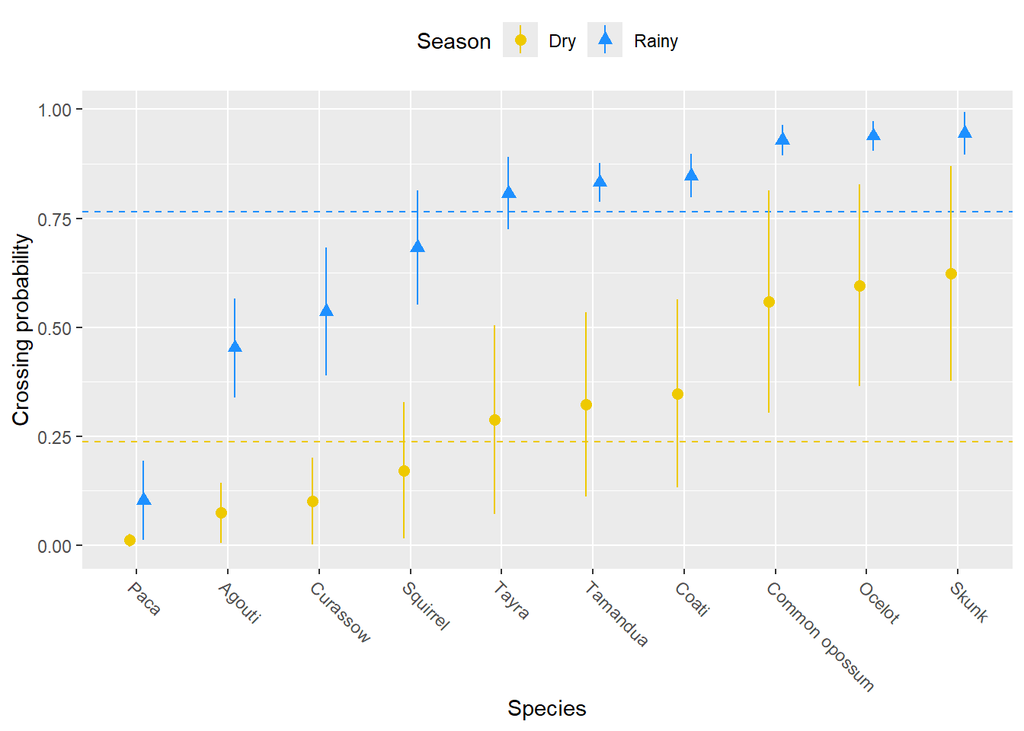

Random effect of species on the intercept in the mixed effects model of crossing probability

Plot with data points

```
## # A tibble: 15 × 3
##    species        season  prop
##    <chr>          <chr>  <dbl>
##  1 agouti         rainy  0.364
##  2 agouti         dry    0
##  3 coati          rainy  0.864
##  4 coati          dry    0
##  5 ocelot         rainy  0.925
##  6 ocelot         dry    1
##  7 opossum_common rainy  0.948
##  8 paca           rainy  0
##  9 skunk_striped  rainy  0.923
## 10 skunk_striped  dry    0.5
## 11 tamandua       rainy  0.811
## 12 tamandua       dry    0
## 13 tayra          rainy  0.810
## 14 curassow_great rainy  0.333
## 15 squirrel_uid   rainy  0.636
```

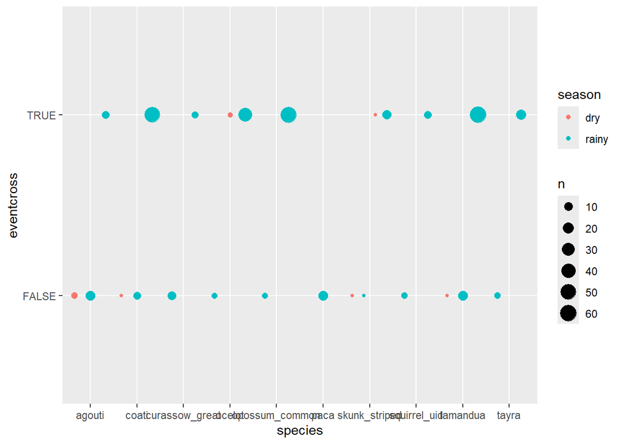

### Noteworthy behaviors

```
## # A tibble: 22 × 3
##    species        behavior           n
##    <chr>          <chr>          <int>
##  1 agouti         marking            2
##  2 coati          marking           23
##  3 coati          scent-marking      1
##  4 opossum_common jumping off        1
##  5 opossum_common marking            1
##  6 opossum_common urinating          1
##  7 opossum_common young in pouch     1
##  8 opossum_uid    jumping off        1
##  9 otter          jumping off        1
## 10 paca           in river           8
## # ℹ 12 more rows
```

We see that many species use the logs, at multiple stations more than 10 different species were observed. This means that these features may be acting also as ways of communicating across and within species. In fact, we observed coatis (n = 23), common opossums (n = 1), striped skunks (n = 17), scent-marking on the logs. We also observed tamanduas defecating on logs on two occasions. It could be worth exploring whether these logs are important marking sites for territorial animals, and whether scent-marking prevents use by conspecifics. In addition to scent-marking sites, logs may act as a food source. We observed tamanduas and striped skunks foraging by removing the tree bark and searching for ants underneath, 10 times for tamanduas, but only once for skunks. We have observed this behavior in previous studies in the same area, so it is unlikely that logs across rivers constitute a more important source of food than logs fallen in the forest.

### Time to event

Another interesting analysis is the delay between detections of different individuals. Considering the scent-marking behavior, it is possible that individuals may be deterred from approaching or crossing the log if a conspecific, or a potential predator, has recently crossed. We follow the approach in [@Niedballa2019], who estimate the delay between detections at every site. For two species A and B, if there is avoidance or attraction of one with respect to the other, then the lag of A after B may be different than the lag of B after A. The effect is estimated using a linear model, with the log-transformed lags as a response variable.

#### Model

```
## $`coati-opossum_common`
##   spp                    t_pred             df   p
## 1 "coati-opossum_common" "888.69206353952"  "58" "3.76306746197315e-05"
## 2 "opossum_common-coati" "630.890598564143" "58" "3.76306746197315e-05"
##   beta
## 1 "0.0767478548158068"
## 2 "0.0767478548158068"
##
## $`coati-skunk_striped`
##   spp                   t_pred             df   p
## 1 "coati-skunk_striped" "908.851851851851" "11" "0.0671848865887145"
## 2 "skunk_striped-coati" "454.616666683831" "11" "0.0671848865887145"
##   beta
## 1 "0.34114914989179"
## 2 "0.34114914989179"
##
## $`opossum_common-skunk_striped`
##   spp                            t_pred             df   p
## 1 "opossum_common-skunk_striped" "475.826666666676" "17" "0.0277727351559463"
## 2 "skunk_striped-opossum_common" "1087.52592592593" "17" "0.0277727351559463"
##   beta
## 1 "0.343524255103278"
## 2 "0.343524255103278"
##
## $`opossum_common-tamandua`
##   spp                       t_pred             df   p
## 1 "opossum_common-tamandua" "1042.55757575758" "16" "0.0866632057166075"
## 2 "tamandua-opossum_common" "670.666666669267" "16" "0.0866632057166075"
##   beta
## 1 "0.241677208287032"
## 2 "0.241677208287032"
##
## $`opossum_common-tayra`
##   spp                    t_pred             df  p
## 1 "opossum_common-tayra" "457.100000000013" "6" "0.0901094989679578"
## 2 "tayra-opossum_common" "821.691666666666" "6" "0.0901094989679578"
##   beta
## 1 "0.290569460484541"
## 2 "0.290569460484541"
```

#### Observed time differences

The following is the mean observed time difference between detections of a focal species and any other species at a given site

```
## # A tibble: 7 × 3
##   sp2            tmean    tsd
##   <chr>          <dbl>  <dbl>
## 1 skunk_striped  14.4   6.48
## 2 coati          14.1   5.90
## 3 tamandua       13.3   6.83
## 4 ocelot         12.6  10.8
## 5 opossum_common 11.1   5.78
## 6 tayra          11.0   5.26
## 7 curassow_great  2.33  0.374
```

This is the difference for the same species

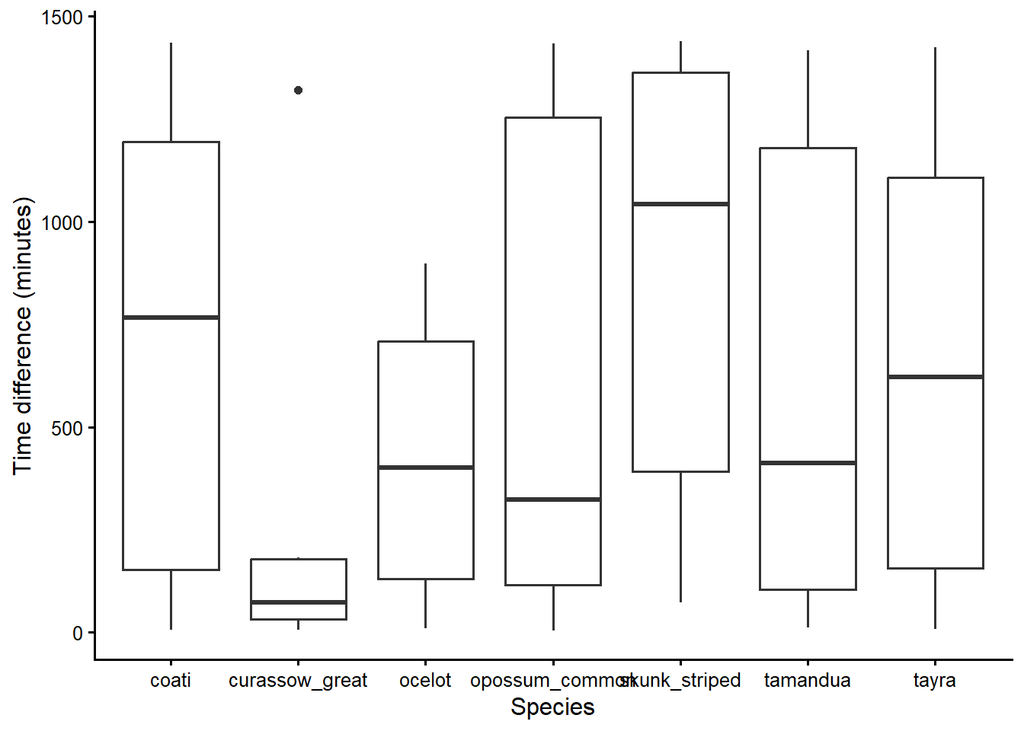

These are the values for waiting time for the same species

```
## # A tibble: 7 × 3
##   sp2            tmean   twd
##   <chr>          <dbl> <dbl>
## 1 coati          11.5   8.90
## 2 curassow_great  3.92  7.39
## 3 ocelot          7.11  5.60
## 4 opossum_common 10.0   9.22
## 5 skunk_striped  14.8   8.79
## 6 tamandua        9.96  8.74
## 7 tayra          10.9   8.74
```

Plot this

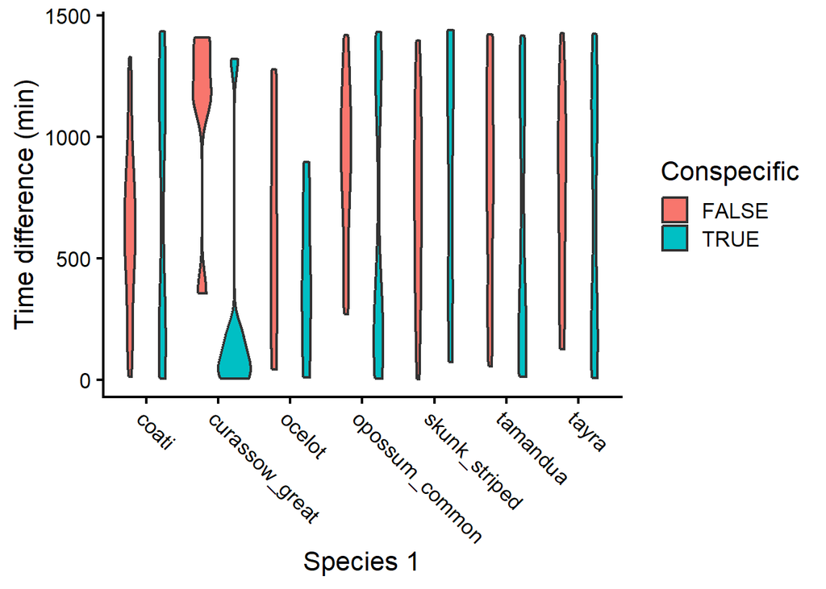

#### Model Summaries

```
## $`coati-opossum_common`
##
## Call:
## glm(formula = tdif ~ sppair, family = gaussian(link = "log"),
##     data = x)
##
## Coefficients:
##                            Estimate Std. Error t value Pr(>|t|)
## (Intercept)                 6.78975    0.05336 127.234  < 2e-16 ***
## sppairopossum_common-coati -0.34262    0.07675  -4.464 3.76e-05 ***
## ---
## Signif. codes:  0 '***' 0.001 '**' 0.01 '*' 0.05 '.' 0.1 ' ' 1
##
## (Dispersion parameter for gaussian family taken to be 47231.26)
##
##     Null deviance: 3646499  on 59  degrees of freedom
## Residual deviance: 2739299  on 58  degrees of freedom
## AIC: 820
##
## Number of Fisher Scoring iterations: 4
##
##
## $`coati-skunk_striped`
##
## Call:
## glm(formula = tdif ~ sppair, family = gaussian(link = "log"),
##     data = x)
##
## Coefficients:
##                           Estimate Std. Error t value Pr(>|t|)
## (Intercept)                 6.8122     0.1079  63.121 1.95e-15 ***
## sppairskunk_striped-coati  -0.6927     0.3411  -2.031   0.0672 .
## ---
## Signif. codes:  0 '***' 0.001 '**' 0.01 '*' 0.05 '.' 0.1 ' ' 1
##
## (Dispersion parameter for gaussian family taken to be 86586.89)
##
##     Null deviance: 1523824  on 12  degrees of freedom
## Residual deviance:  952450  on 11  degrees of freedom
## AIC: 188.52
```

[output cut: 53 more lines]

```
##
## Coefficients:
##                            Estimate Std. Error t value Pr(>|t|)
## (Intercept)                  6.1249     0.2539  24.121 3.34e-07 ***
## sppairtayra-opossum_common   0.5865     0.2906   2.018   0.0901 .
## ---
## Signif. codes:  0 '***' 0.001 '**' 0.01 '*' 0.05 '.' 0.1 ' ' 1
##
## (Dispersion parameter for gaussian family taken to be 53887.77)
##
##     Null deviance: 589181  on 7  degrees of freedom
## Residual deviance: 323327  on 6  degrees of freedom
## AIC: 113.56
##
## Number of Fisher Scoring iterations: 5
```

This figure shows the observed lags in minutes for the species pairs that we found a difference for.

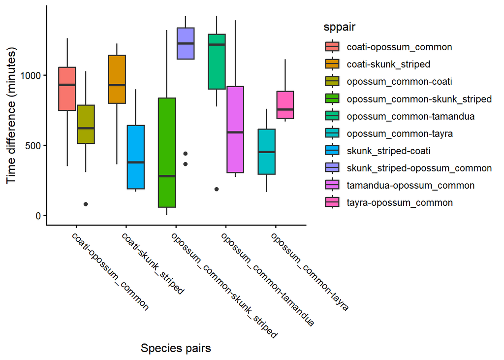